# StatCompHomwork_20088

Youjie_Zeng_20088

2020/12/15

## All homework of StatComp (Fall term,2020) by Youjie Zeng (ID: 20088)

This is an R Markdown document which includes all of the homework during the author studying the lesson, Statistical Computing (lecturer: Prof.Zhang, Fall,2020).

## 2020/9/28

## Example 1.

Create an example containing text and at least one figure.

## Example 2.

Create an example containing texts and at least one table.

## Answer

This is a table of grades in USTC.

| Class | GPA | grade |
| --- | --- | --- |
| A+ | 4.3 | 100~95 |
| A | 4.0 | 94~90 |
| A- | 3.7 | 89~85 |
| B+ | 3.3 | 84~82 |
| B | 3.0 | 81~78 |
| B- | 2.7 | 77~75 |
| C+ | 2.3 | 74~72 |
| C | 2.0 | 71~68 |
| C- | 1.7 | 67~65 |
| D+ | 1.5 | 64 |
| D | 1.3 | 63~61 |
| D- | 1.0 | 60 |
| F | 0.0 | <60 |

## Example 3.

Create an example containing at least a couple of LaTeX formulas.

## Answer

Maxwell’s equations
$$\begin{align*}
\nabla \times \boldsymbol{H} &= \boldsymbol{J} + \frac{\partial \boldsymbol{D}}{\partial t},\\
\nabla \times \boldsymbol{E} &= -\frac{\partial \boldsymbol{B}}{\partial t},\\
\nabla \cdot \boldsymbol{B} &= 0,\\
\nabla \cdot \boldsymbol{D} &= 0.
\end{align*}$$

## 2020/9/29

## Ex 3.3

The Pareto(a, b) distribution has cdf
$$F(x) = 1 - \left(\frac{b}{x}\right)^a, x \geq b>0, a > 0$$
Derive the probability inverse transformation $F^{-1}(U)$ and use the inverse transform method to simulate a random sample from the Pareto(2, 2) distribution. Graph the density histogram of the sample with the Pareto(2, 2) density superimposed for comparison

## Answer

The inverse transformation is $X = F^{-1}(U) = b(1-U)^{-1/a}$. The density is $f(x)=ab^a \left(\frac{1}{x}\right)^{a+1}$. We generate 1000 samples from the uniform distribution $U(0,1)$ and use the inverse transformation to obtain the coresponding samples from the distribution Pareto(2,2) as the follow.

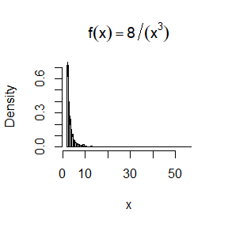

```r
set.seed(12)
n <- 1000
a <- 2
b <- 2
u <- runif(n)
x <- b*(1-u)^(-1/a)
f <- function(x) fx <- 8/(x^3)
hist(x,prob=TRUE,breaks=length(x)/10,main = expression(f(x)==8/(x^3)))
y <- seq(2,max(x),0.1)
lines(y,f(y))
```

## Ex 3.9

The rescaled Epanechnikov kernel [85] is a symmetric density function
$$f_e ( x) = \frac{3}{4} (1-x^2), |x|\leq 1 .$$
Devroye and Gy$\ddot{\text{o}}$rfi [71, p. 236] give the following algorithm for simulation from this distribution. Generate iid $U_1, U_2, U_3 \sim Uniform(-1,1)$. If $|U_3| \geq |U_2|$ and $|U_3| \geq |U_1|$, deliver $U_2$; otherwise deliver $U_3$. Write a function to generate random variates from $f_e$, and construct the histogram density estimate of a large simulated random sample.

## Answer

The procedure is shown as follow:

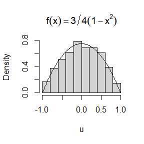

```r
deliver <- function(x,y,z){
  if(abs(z)>=abs(y)&abs(z)>=abs(x)) return(y)
  else return(z)
} # choose u from u1,u2,u3
f_e <- function(x) 0.75*(1-x^2)
set.seed(123)
n <- 1000
u1 <- runif(n,min = -1,max = 1)
u2 <- runif(n,min = -1,max = 1)
u3 <- runif(n,min = -1,max = 1)
u <- numeric(n)
for (i in 1:n) {
  u[i]<- deliver(u1[i],u2[i],u3[i])
}
x <- seq(-1,1,0.01)
hist(u,prob=TRUE,main = expression(f(x)==3/4 (1-x^2)))
lines(x,f_e(x))
```

## Ex 3.10

Prove that the algorithm given in Exercise 3.9 generates variates from the density $f_e$ (3.10).

## Proof

It is obvious that $|U_1|,|U_2|,|U_3| i.i.d \sim U(-1,1)$. Let $U$ be the generated variate, and $U$ has a symmetric distribution on interval $(-1,1)$. We shall consider $|U|$ first, then conduct the result from the distribution of $|U|$ on $(0,1)$ through its symmetry. Let $X,Y,Z i.i.d \sim U(0,1)$, if $Z\geq Y, Z\geq X$,then $W = Y$; otherwise, $W = Z$. We conduct the distribution of $W$.

Since the symmetry, $W=Y$ and $W=X$ are equivalent when $Z\geq Y, Z\geq X$. When $Z<Y$ or $Z<X$, $W=Z$ means that $W<X,W<Y$. In general, $W$ is always one of the two smallest of $X,Y,Z$.

Consider the event $\{W \leq t\}, t\in (0,1)$, and there must exist at least one of $X,Y,Z$ lie in (0,t). We discuss it in the two ways:

1. There exactly exists one of $X,Y,Z$ that lies in (0,t), and we obtain $\{W\leq t\}$ with probablity $\frac{1}{2}$, then the coresponding probablity is
   $$\left(
   \begin{array}{c}
   3\\
   1
   \end{array}
   \right) t(1-t)^2 \times \frac{1}{2} = \frac{3}{2} t(1-t)^2.$$
2. There exist at least two of $X,Y,Z$ lie in $(0,t)$, then the coresponding probablity is

$$\left(
\begin{array}{c}
3\\
2
\end{array}
\right) t^2(1-t)
+
\left(
\begin{array}{c}
3\\
3
\end{array}
\right) t^3 = t^2 (3-2t)$$

Then, he cdf of $Z=|U|$ is
$$F_Z (t)= P(W\leq t) = \frac{3}{2} t(1-t)^2 + t^2 (3-2t) = \frac{3}{2} t - \frac{t^3}{2}.$$
Last, we conduct the cdf of $U$ through its symmetry. Define
$$U=\left\{ \begin{array}{c}
Z, \ \ p=\frac{1}{2} \\
-Z, \ \ p = \frac{1}{2}
\end{array}
\right.$$
Then the cdf of $U$ is
$$F_U (u)=\left\{ \begin{array}{c}
\frac{1}{2} + \frac{1}{2} F_Z(u), \ \ u \geq 0, \\
\frac{1}{2} (1-F_Z(-u)), \ \ u<0.
\end{array}
\right.$$
Therefore, the density of $U$ is
$$F'(u) = \frac{1}{2} F'_Z(u) = \frac{3}{4}(1-u^2) = f_e (u).$$
That is the result we want.

## Ex 3.13

It can be shown that the mixture in Exercise 3.12 has a Pareto distribution with cdf
$$F(y) = 1 - \left( \frac{\beta}{\beta + y}\right)^r, y \geq 0.$$
(This is an alternative parameterization of the Pareto cdf given in Exercise 3.3.) Generate 1000 random observations from the mixture with $r = 4$ and $\beta = 2$. Compare the empirical and theoretical (Pareto) distributions by graphing the density histogram of the sample and superimposing the Pareto density curve.

## Answer

1. For $y\geq 0$,
   $$\begin{align}
   F(y) = P(Y\leq y) &= \int_0^\infty P(Y\leq y | \Lambda = \lambda) f_G(\lambda) d \lambda\\
   &=\int_0^\infty \left(1-e^{-\lambda y}\right) \frac{\beta^\gamma \lambda^{\gamma - 1} e^{-\beta \lambda}}{\Gamma(\gamma)} \\
   &= 1 - \frac{\beta^\gamma }{\Gamma(\gamma)} \int_0^\infty \lambda^{\gamma - 1} e^{-(\beta + y)\lambda} d\lambda \\
   &= 1- \frac{\beta^\gamma }{\Gamma(\gamma)} \frac{\Gamma(\gamma)}{(\beta+y)^\gamma } \\
   &= 1- \left(\frac{\beta}{\beta + y}\right)^\gamma
   \end{align}$$
   That is exactly a pareto distribution cdf.
2. With $\gamma = 4$ and $\beta=2$, the density is
   $$f(y) = \frac{64 }{(2 + y)^{5}}.$$
   We compare the empirical and theoretical (Pareto) distributions as follow.

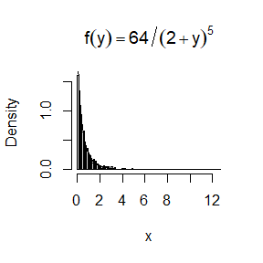

```r
set.seed(313)
n <- 1000
r <- 4
beta <- 2
lambda <- rgamma(n,r,beta)
x <- rexp(n,lambda)
y <- seq(0,max(x),length.out = n)
hist(x,prob=TRUE,breaks=100,main = expression(f(y)==64/ (2+y)^5))
lines(y,64/(2+y)^5)
```

## 2020/9/29

## Ex 5.1

Compute a Monte Carlo estimate of
$$\int_0^{\frac{\pi}{3}} sin t\ \ dt$$
and compare your estimate with the exact value of the integral.

## Answer

Let $X \sim U(0,\pi/3)$, then
$$\int_0^{\frac{\pi}{3}} sin t\ \ dt = \frac{\pi}{3}\int_0^{\frac{\pi}{3}} sint \frac{3}{\pi} d t = \frac{\pi}{3} E[sin(X)].$$
Using MC, we have

```r
set.seed(51)
m <- 1e4
x <- runif(m, min=0, max=pi/3)
theta.hat <- mean(sin(x)) * pi/3
print(c(theta.hat,cos(0)-cos(pi/3)))
```

```
## [1] 0.4993902 0.5000000
```

## 5.7

Refer to Exercise 5.6. Use a Monte Carlo simulation to estimate $\theta$ by the antithetic variate approach and by the simple Monte Carlo method. Compute an empirical estimate of the percent reduction in variance using the antithetic variate. Compare the result with the theoretical value from Exercise 5.6

## Answer

Consider $U_1 \sim U(0,1)$, then $E[e^{U_1}] = \theta$, i.e. $e^{U_1}$ is an unbiased estimator of $\theta$. Similarly, $U_2 = 1 - U_1 \sim U(0,1)$ and $E[e^{U_2}]$ is an unbiased estimator of $\theta$. Use antithetic variate approach to estimate $\theta$:

```r
set.seed(57)
m <- 1e4
# Antithetic variate approach function
AV.appro <- function(R){
  u1 <- runif(R/2,0,1)
  u2 <- 1- u1
  u <- c(u1,u2)
  theta.hat.a <- mean(exp(u))
  return(theta.hat.a)
}

# simple MC
simpleMC <- function(R){
  x <- runif(R,0,1)
  theta.hat.s <- mean(exp(x))
  return(theta.hat.s)
}

# the coresponding estimators
print(c(AV.appro(m),simpleMC(m),exp(1)-1))
```

```
## [1] 1.719967 1.713935 1.718282
```

```r
# compare sd
n <- 1000
MC1 <- numeric(n)
MC2 <- numeric(n)

for (i in 1:n) {
  MC1[i] <- AV.appro(m)
  MC2[i] <- simpleMC(m)
}
print(c(sd(MC1),sd(MC2),sd(MC1)/sd(MC2),1-sd(MC1)/sd(MC2)))
```

```
## [1] 0.0008813438 0.0050724198 0.1737521362 0.8262478638
```

The above result shows the reduction in variance. Last, we will compare it with the theorical results from Ex 5.6: let $U \sim U(0,1)$,

$$Cov(e^U,e^{1-U}) = E[e^U\cdot e^{1-U}] - E[e^U]\cdot E[e^{1-U}] = e - \theta^2.$$
$$\begin{align}
Var(e^U + e^{1-U}) &= Var(e^U) + Var(e^{1-U}) + Cov(e^U,e^{1-U})\\
&= \int_0^1 e^{2u} du - \theta^2 + \int_0^1 e^{2-2u} du - \theta^2 +2e - 2\theta^2\\
&= (e^2-1) + 2e -4(e-1)^2\\
&= 0.01564999\\
Var(\frac{e^{U} + e^{1-U}}{2}) &= \frac{1}{4}Var(e^U + e^{1-U}) = 0.003912497\\
Var(e^{U}) &= 0.2420356
\end{align}$$
$$\text{percent redunction of variance} = 1 - \frac{Var(\frac{e^U + e^{1-U}}{2})}{Var(e^{U})}= 0.983835$$
$$\text{percent redunction of sd} = 1 - \left(\frac{Var(\frac{e^U + e^{1-U}}{2})}{Var(e^{U})}\right)^{\frac{1}{2}}= 0.8728585$$
As above, the simulated reduction of sd (0.8262478638) is close to the theorical result (0.8728585).

## 5.11

If $\widehat{\theta}_1$ and $\widehat{\theta}_2$ are unbiased estimators of $\theta$, and $\widehat{\theta}_1$ and $\widehat{\theta}_2$ are antithetic, we derived that $c^* = 1/2$ is the optimal constant that minimizes the variance of $\widehat{\theta}_c = c\widehat{\theta}_1 + (1-c)\widehat{\theta}_2$. Derive $c^*$ for the general case. That is, if $\widehat{\theta}_1$ and $\widehat{\theta}_2$ are any two unbiased estimators of $\theta$, find the value $c^*$ that minimizes the variance of the estimator $\widehat{\theta}_c = c\widehat{\theta}_1 + (1-c)\widehat{\theta}_2$ in equation (5.11).($c^*$ will be a function of the variances and the covariance of the estimators.)

## Answer

Let $p=Var(\widehat{\theta}_1),q=Var(\widehat{\theta}_2)$ and $r=Cov(\widehat{\theta}_1,\widehat{\theta}_2)$. Then
$$\begin{align}
f(c) = Var(\widehat{\theta}_c) &= c^2 Var(\widehat{\theta}_1) + (1-c)^2 Var(\widehat{\theta}_2) + 2c(1-c) Cov (\widehat{\theta}_1,\widehat{\theta}_2)\\
& = pc^2 + q(1-c)^2 + 2rc(1-c)\\
&= (p+q - 2r) c^2 + 2(r-q)c +q
\end{align}$$
Since $p + q - 2r >0$ and $\Delta < 0$, $f(c)$ has the positive minimum value $f(c^*)$ where $c^*$ is the minimizer of $f$ and has the expression as follow:
$$\begin{align}
c^* = \frac{q-r}{p+q-2r} = \frac{Var(\widehat{\theta}_2) - Cov(\widehat{\theta}_1,\widehat{\theta}_2)}{Var(\widehat{\theta}_1)+Var(\widehat{\theta}_2)-2Cov(\widehat{\theta}_1,\widehat{\theta}_2)}
\end{align}$$

## 2020/10/20

## Ex 5.13

Find two importance functions $f_1$ and $f_2$ that are supported on $(1,\infty)$ and are ‘close’ to
$$g(x)=\frac{x^2}{\sqrt{2\pi}}e^{-x^2/2},\ \ x>1.$$
Which of your two importance functions should produce the smaller variance in estimating
$$\int_1^\infty\frac{x^2}{\sqrt{2\pi}}e^{-x^2/2}dx$$
by importance sampling? Explain.

## Answer

The two importance functions (p.d.f) are shown as follow:
$$\begin{align}
f_1(x) &= e^{-(x-1)},\ \ x>1,\\
f_2(x) &= \frac{\pi}{4} \frac{1}{1+x^2}, x>1.
\end{align}$$

For $f_1$, we generated $x$’s from the exponential distribution $EXp(1)$ then use $x+1$ as samples.

For $f_2$, we use the inverse transform method by using the result $F(U)\sim U(0,1)$ where $F$ is the cdf of $r.v. U$.

The codes and results are shown as follow:

```r
set.seed(513)
m <- 10000
theta.hat <- se <- numeric(2)

g <- function(x){x^2*exp(-0.5*x^2)/sqrt(2*pi)}

# f_1
x.1 <- rexp(m,1)
x.1 <- x.1+1
fg <- g(x.1) / exp(-x.1+1)
theta.hat[1] <- mean(fg)
se[1] <- sd(fg)

#f_2
u <- runif(m)
x.2 <- tan((1+u)*pi/4)
fg <- g(x.2) / (4 / ((1 + x.2^2) * pi))
theta.hat[2] <- mean(fg)
se[2] <- sd(fg)

#result
rbind(theta.hat, se)
```

```
##                [,1]      [,2]
## theta.hat 0.4000968 0.4018054
## se        0.1579389 0.3298760
```

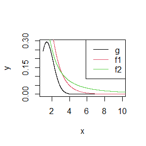

```r
x.1 <- sort(x.1)
x.2 <- sort(x.2)
x <- seq(1,10,length.out = m)
y <- g(x)
plot(x,y,type='l')
lines(x.1,exp(-x.1+1),col=2)
lines(x.2,(4 / ((1 + x.2^2) * pi)),col=3)
legend("topright",legend = c('g','f1','f2'),col=1:3,lty=1)
```

From the result, $f_1$ produces the smaller variance in estimating the integral since $f_1$ is ‘closer’ to g and $f_2$ is heavy-tail which cause more fluction.

## Ex 5.15

Obtain the stratified importance sampling estimate in Example 5.13 and compare it with the result of Example 5.10.

## Answer

In this exercise, we want to approximate the integral
$$\int_0^1\frac{e^{-x}}{1+x^2}dx$$
by stratified sampling. For $j=0,1,2,3,4$, consider the following importance funcitns:
$$f_j (x) = \frac{e^{-x}}{e^{-\frac{j-1}{5}}-e^{-\frac{j}{5}}}, \frac{j-1}{5}<x<\frac{j}{5}.$$

Let $C_j = e^{-\frac{j-1}{5}}-e^{-\frac{j}{5}},j=0,1,,2,3,4$, then the c.d.f’s are
$$F_j(x)=\frac{1}{C_j} \left(e^{-\frac{j-1}{5}}-e^{-x}\right), \frac{j-1}{5}<x<\frac{j}{5}.$$
Use the transform method, $U_j = F_j(X) \sim U(0,1)$, then
$$X_j = F^{-1}(U_j) = -\log\left(e^{-\frac{j-1}{5}} - C_j U_j\right).$$

```r
set.seed(515)
M <- 10000;
k <- 5 # what if k is larger?
r <- M/k #replicates per stratum

g <- function(x){exp(-x)/(1+x^2)}

f <- function(x,j){
  C <- exp(-0.2*(j-1))-exp(-0.2*j)
  p <- exp(-x)/C
}

X.trans <- function(u,j){
  C <- exp(-0.2*(j-1))-exp(-0.2*j)
  x <- -log(exp(-0.2*(j-1))-C*u)
  return(x)
}

theta.hat <- sd <- numeric(k)

for (j in 1:5) {
  u <- runif(r)
  x <- X.trans(u,j)
  fg <- g(x)/f(x,j)
  theta.hat[j+1] <- mean(fg)
  sd[j+1] <- sd(fg)
}
theta.total <- sum(theta.hat)
sd.total <- sqrt(sum(sd^2))
#names(theta.total)="theta"
#names(sd.total)="sd"
c(theta.total,sd.total)
```

```
## [1] 0.525144981 0.007861295
```

In Example 5.10, the esitimated value and sd are $0.52506988$ and $0.09658794$, respectively. The performance of stratified sampling is better, it has the smaller variance.

## Ex 6.4

Suppose that $X_1,...,X_n$ are a random sample from a from a lognormal distribution with unknown parameters. Construct a $95\%$ confidence interval for the parameter $\mu$. Use a Monte Carlo method to obtain an empirical estimate of the confidence level.

## Answer

Let $Z \sim N(0,1)$, $\mu \in \mathbf{R},\sigma >0$ are unknown parameters, then $X=e^{\mu + \sigma Z}$ has the log-normal distribution. Let $\mu^* = e^{\mu}, \sigma^* = e^\sigma$, for normal distribution $N(\mu,\sigma^2)$, the $95\%$ confidence interval is $(\widehat{\mu}-t_{n-1}(0.975)\cdots e,\widehat{\mu}+t_{n-1}(0.975)\cdot se)$ where $se = \widehat{\sigma}/\sqrt{n}$ and $t_{n-1}(0.975)$ is the $97.5\%$ quantile of a $t$-distribution with $n-1$ degrees of freedom. Then the coresponding %95%% confidence interval of log-normal distribution is
$$\left(\widehat{\mu^*}/{\left(\widehat{\sigma^*}\right)^{t_{n-1}(0.975)/\sqrt{n}}},\widehat{\mu^*}\cdot{\left(\widehat{\sigma^*}\right)^{t_{n-1}(0.975)/\sqrt{n}}}\right),$$
where $\widehat{\mu^*} = e^{\widehat{\mu}}, \widehat{\sigma^*} = e^{\widehat{\sigma}}$ and it is easy to conduct
$$\begin{align}
\widehat{\mu} &= \frac{1}{n} \sum_{i=1}^n \ln X_i \\
\widehat{\sigma}^2 &= \frac{1}{n-1} \sum_{i=1}^n \left(\ln X_i - \widehat{\mu}\right)^2
\end{align}$$

Next, we use MC method to obtain an empirical estimate of the confidence level:

```r
mu <- 0
sigma <- 2
m <- 1000
n <- 10

set.seed(64)
mu.hat <- mu.se <- UCL <- numeric(m)

calcCI <- function(n,mu,sigma){
  x <- rlnorm(n,meanlog = 0,sdlog = 2)
  mu.hat <- sum(log(x))/n
  sigma.hat <- sum((log(x)-mu.hat)^2)/(n-1)
  A <- exp(sqrt(sigma.hat))^{qt(0.975,df=n-1)/sqrt(n)}
  CI.left <- exp(mu.hat)/A
  CI.right <- exp(mu.hat)*A
  names(CI.left) <- "Lowbound"
  names(CI.right) <- "Upbound"
  return(c(CI.left,CI.right))
}

for (i in 1:m) {
  result <- calcCI(n,0,2)
  low <- result[1]
  up <- result[2]
  UCL[i] <- low<1&up>1
}
sum(UCL)/m
```

```
## [1] 0.952
```

From the simulted proportion that the true value located in the empirical CI, we can show that such a mathod to conduct CI is efficient.

## Ex 6.5

Suppose a $95\%$ symmetric $t$-interval is applied to estimate a mean, but the sample data are non-normal. Then the probability that the confidence interval covers the mean is not necessarily equal to $0.95$. Use a Monte Carlo experiment to estimate the coverage probability of the $t$-interval for random samples of $\chi^2 (2)$ data with sample size $n = 20$. Compare your $t$-interval results with the simulation results in Example 6.4. (The t-interval should be more robust to departures from normality than the interval for variance.)

## Answer

The mean of $\chi^2(2)$ is $2$. We do the simulation similar to Ex 6.4 but the samples are generated from $\chi^2(2)$.

```r
mu <- 0
sigma <- 2
m <- 1000
n <- 20

set.seed(651)
mu.hat <- mu.se <- UCL <- numeric(m)

calcCI <- function(n){
  x <- rchisq(n,df=2)
  mu.hat <- sum(log(x))/n
  sigma.hat <- sum((log(x)-mu.hat)^2)/(n-1)
  A <- exp(sqrt(sigma.hat))^{qt(0.975,df=n-1)/sqrt(n)}
  CI.left <- exp(mu.hat)/A
  CI.right <- exp(mu.hat)*A
  names(CI.left) <- "Lowbound"
  names(CI.right) <- "Upbound"
  return(c(CI.left,CI.right))
}

for (i in 1:m) {
  result <- calcCI(n)
  low <- result[1]
  up <- result[2]
  UCL[i] <- low<2&up>2
}
sum(UCL)/m
```

```
## [1] 0.516
```

The variance of $\chi^2(2)$ is 4. When t-interval is applied to esitiamting the CI for variance:

```r
set.seed(652)
m <-1000
n <- 20
alpha <- .05
UCL <- numeric(m)
for (i in 1:m) {
  x <- rnorm(n, mean=0, sd=2)
  Upbound <- (n-1) * var(x) / qchisq(alpha,df=n-1)
  UCL[i] <- Upbound>4
}
sum(UCL/m)
```

```
## [1] 0.95
```

The simulated proportion that the esitimated CI contains true variance is $0.95$, which is equal to the theorical one.

## 2020/10/27

## 6.7

Estimate the power of the skewness test of normality against symmetric Beta($\alpha,\alpha$) distributions and comment on the results. Are the results different for heavy-tailed symmetric alternatives such as $t(\nu)$?

## Answer

The skewness $\sqrt{\beta_1}$ of a random variable $X$ is defined by
$$\sqrt{\beta_1} = \frac{E[(X-\mu_X)]^3}{\sigma^2_X},$$
where $\mu_X = E[X]$ and $\sigma_X^2 = Var(X)$. We consider a hypothesis of normalilty for distribution $Beta(\alpha,\alpha)$ as follow
$$H_0:\sqrt{\beta_1}=0;\ \ \ \ \ H_1:\sqrt{\beta_1}\neq 0.$$
And the test statistic is the coefficient of skewness $\sqrt{b_1}$ defined as
$$\sqrt{b_1}=\frac{ \frac{1}{n}\sum_{i=1}^n(X_i - \bar{X})^3}{(\frac{1}{n}\sum_{i=1}^n(X_i-\bar{X})^2)^{3/2}},$$
where the samples are generated from $Beta(\alpha,\alpha)$. We start the simulation and set $\alpha=2$

```r
set.seed(67)

nu <- 2
alpha <- 2

n <- c(10, 20, 30, 50, 100, 500) #sample sizes
cv <- qnorm(.975, 0, sqrt(6/n)) #crit. values for each n

sk <- function(x) {
  #computes the sample skewness coeff.
  xbar <- mean(x)
  m3 <- mean((x - xbar)^3)
  m2 <- mean((x - xbar)^2)
  return( m3 / m2^1.5 )
}

#n is a vector of sample sizes
#we are doing length(n) different simulations
p.reject2 <- p.reject1 <- numeric(length(n)) #to store sim. results
m <- 10000 #num. repl. each sim.
for (i in 1:length(n)) {
sktests2 <- sktests1 <- numeric(m) #test decisions

# beta(alpha,alpha) distribution
for (j in 1:m) {
x1 <- rbeta(n[i],alpha,alpha)
#test decision is 1 (reject) or 0
sktests1[j] <- as.integer(abs(sk(x1)) >= cv[i] )
}
p.reject1[i] <- mean(sktests1) #proportion rejected
}
# t distribution
for (i in 1:length(n)) {
sktests2 <- numeric(m) #test decisions
for (j in 1:m) {
x2 <- rt(n[i],2)
#test decision is 1 (reject) or 0
sktests2[j] <- as.integer(abs(sk(x2)) >= cv[i] )
}
p.reject2[i] <- mean(sktests2) #proportion rejected
}

p.reject1 # for beta(alpha,alpha)
```

```
## [1] 0.0039 0.0028 0.0018 0.0017 0.0014 0.0009
```

```r
p.reject2 # for t(nu)
```

```
## [1] 0.1961 0.4511 0.5676 0.6925 0.8122 0.9387
```

The proportion rejected is small which indicates that we shall accept the null hypothesis. In practice, $Beta(\alpha,\alpha)$ is a symmetric distribution illustrated by the following pdf curves:

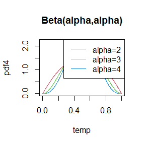

```r
temp <- seq(0,1,length.out = 1000)
pdf2 <- temp*(1-temp)/beta(2,2)
pdf3 <- temp^2*(1-temp)^2/beta(3,3)
pdf4 <- temp^3*(1-temp)^3/beta(4,4)
plot(temp,pdf4,main = "Beta(alpha,alpha)",type = "l",col=4)
lines(temp,pdf3,col=3)
lines(temp,pdf2,col=2)
legend("topright",legend = c('alpha=2','alpha=3','alpha=4'),col=2:4,lty=1)
```

On the other hand, student t distibution $t(\nu)$ is also a symmetric distribution but heavy-tailed, and the proportion rejected raises as the sample size growing, which means that in the heavy-tailed case, $\sqrt{b_1}$ is not a good test statistic and it will lead to the mistake.

## Ex 6.8

Refer to Example 6.16. Repeat the simulation, but also compute the F test of equal variance, at significance level $\hat{\alpha} = 0.055$. Compare the power of the Count Five test and $F$ test for small, medium, and large sample sizes. (Recall that the F test is not applicable for non-normal distributions.)

## Answer

We set sample sizes as $10, 20, 30, 50, 100, 500$ and compare the proportions rejected of Count5test and F test.

```r
# generate samples under H1 to estimate power
set.seed(68)

sigma1 <- 1
sigma2 <- 1.5
n <- c(10, 20, 30, 50, 100, 500) # sample size
m <- 1e4


# The function count5test returns the value 1
# (reject H0) or 0 (do not reject H0)
count5test <- function(x, y) {
X <- x - mean(x)
Y <- y - mean(y)
outx <- sum(X > max(Y)) + sum(X < min(Y))
outy <- sum(Y > max(X)) + sum(Y < min(X))
# return 1 (reject) or 0 (do not reject H0)
return(as.integer(max(c(outx, outy)) > 5))
}

power <- Ftest <- numeric(m)
por.power <- por.Ftest <-  numeric(length(n))
for (j in 1:length(n)) {
  for (i in 1:m) {
  x <- rnorm(n[j], 0, sigma1)
  y <- rnorm(n[j], 0, sigma2)
  power[i] <- count5test(x, y)
  Ftest[i] <- var.test(x,y,conf.level = 0.945)$p.value < 0.055
  }
  por.power[j] <- mean(power)
  por.Ftest[j] <- mean(Ftest)
}
# count5test
por.power
```

```
## [1] 0.1082 0.3035 0.4675 0.6622 0.8536 0.9920
```

```r
# F test
por.Ftest
```

```
## [1] 0.2122 0.4100 0.5919 0.8108 0.9827 1.0000
```

Form the above results, both of the proportion rejected of count5test and the proportion rejected of F test raise as sample size growing. And F test always performs better than count5test, whatever for small, medium, and large sample sizes. The proportion rejected is small in the small sample size case but close to 1 in the large sample size, which shows that both of them perform well for large sample size but worse for small sample size.

## Ex 6.C

Repeat Examples 6.8 and 6.10 for Mardia’s multivariate skewness test. Mardia [187] proposed tests of multivariate normality based on multivariate generalizations of skewness and kurtosis. If $X$ and $Y$ are iid, the multivariate population skewness $\beta_{1,d}$,d is defined by Mardia as
$$\beta_{1,d} = E[(X-\mu)^T\Sigma^{-1}(Y-\mu)]^3.$$
Under normality, $\beta_{1,d}=0$. The multivariate skewness statistic is
$$b_{1,d} = \frac{1}{n^2} \sum_{i,j=1}^n ((X_i-\bar{X})^T\widehat{\Sigma}^{-1}(X_j-\bar{X}))^3,$$
where $\hat{\Sigma}$ is the maximum likelihood estimator of covariance. Large values of $b_{1,d}$ are significant. The asymptotic distribution of $nb_{1,d}/6$ is the chisquared with $d(d+1)(d+2)/6$ degrees of freedom.

## Answer

1. Repeat Example 6.8: for the case dimension $d=1$, $\boldsymbol{X}=(X_1,...,X_n)^T$ is the samples, then the estimated covariance by maximizing the likelihood is $\hat{\Sigma} = \frac{1}{n} \sum_{i}^n(X_1-\bar{X})^2$.
   $$b_{1,1}=\frac{1}{n^2}\sum_{i,j=1}^n\left\{(X_i-\bar{X})\left(\frac{1}{n}\sum_{i=1}^n (X_i-\bar{X})^2\right)^{-1}(X_j-\bar{X})\right\}^3= n \left(\sum_{k=1}^n(X_k-\bar{X})^2\right)^{-3}\sum_{i,j=1}^n\left((X_i-\bar{X})(X_j-\bar{X})\right)^3$$

And the critical values are relevent to chi-squared distribution $\chi^2_1$. The codes and result are given as follow:

```r
set.seed(666)
n <- c(10, 20, 30, 50, 100, 500) #sample sizes
cv.6C <- qchisq(.95, 1)#crit. values for each n


sk.6C <- function(x){
  #computes the sample skewness coeff by  Mardia's approach.
  len <- length(x)
  x<- as.matrix(x)
  xbar <- mean(x)
  m1 <- sum((x-xbar)^2)
  mat <- (x-xbar)%*%t(x-xbar)
  mat <- mat^3
  m2 <- sum(mat)
  return(len*m2*m1^(-3))
}
# repeat example 6.8
p.reject.6C1 <- numeric(length(n)) #to store sim. results
m <- 10000 #num. repl. each sim.
for (i in 1:length(n)) {
sktests.6C1 <- numeric(m) #test decisions
for (j in 1:m) {
x <- rnorm(n[i])
#test decision is 1 (reject) or 0
sktests.6C1[j] <- as.integer(n[i]*sk.6C(x)/6 >= cv.6C )
}
p.reject.6C1[i] <- mean(sktests.6C1) #proportion rejected
}
p.reject.6C1
```

```
## [1] 0.0136 0.0291 0.0347 0.0402 0.0450 0.0498
```

```r
#repeat example 6.10


alpha <- .1
n <- 30
m <- 2500
epsilon <- c(seq(0, .15, .01), seq(.15, 1, .05))
N <- length(epsilon)
pwr <- numeric(N)
#critical value for the skewness test
cv <- qnorm(1-alpha, 1)

for (j in 1:N) {   #for each epsilon
e <- epsilon[j]
sktests.6C2 <- numeric(m)
for (i in 1:m) { #for each replicate
sigma <- sample(c(1, 10), replace = TRUE,
size = n, prob = c(1-e, e))
x <- rnorm(n, 0, sigma)
sktests.6C2[i] <- as.integer(n*sk.6C(x)/6 >= cv)
}
pwr[j] <- mean(sktests.6C2)
}
# the proportion rejected
pwr
```

```
##  [1] 0.0892 0.2640 0.4244 0.5216 0.6100 0.6504 0.7216 0.7376 0.7800 0.7828
## [11] 0.8068 0.8060 0.8300 0.8164 0.8060 0.8080 0.8204 0.7692 0.7344 0.6688
## [21] 0.6216 0.5648 0.5028 0.4316 0.3808 0.3280 0.3020 0.2564 0.2088 0.1844
## [31] 0.1616 0.1292 0.0928 0.0924
```

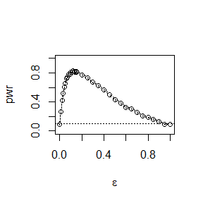

```r
#plot power vs epsilon
plot(epsilon, pwr, type = "b",
xlab = bquote(epsilon), ylim = c(0,1))
abline(h = .1, lty = 3)
se <- sqrt(pwr * (1-pwr) / m) #add standard errors
lines(epsilon, pwr+se, lty = 3)
lines(epsilon, pwr-se, lty = 3)
```

## Discussion

If we obtain the powers for two methods under a particular simulation setting with 10,000 experiments: say, 0.651 for one method and 0.676 for another method. Can we say the powers are different at 0.05 level?

1. What is the corresponding hypothesis test problem?
2. What test should we use? Z-test, two-sample t-test, paired-t test or McNemar test?
3. What information is needed to test your hypothesis?

## Answer

1. Test null hypothesis $H_0: \text{The two methods have the same power.}$
2. We should use McNemar test since it is relevent to the class test.
3. Consider the folowing $2\times2$ McNemar

```r
mat <- matrix(c(6510,3490,10000,6760,3240,10000,13270,6730,20000),3,3,dimnames = list(c("Rejected","Accepted","total"),c("A method","B method","total")))
mat
```

```
##          A method B method total
## Rejected     6510     6760 13270
## Accepted     3490     3240  6730
## total       10000    10000 20000
```

And the test statistic is Pearson
$$\chi^2 = \sum_{i,j=1}^2 \frac{(n_{ij}-n_{i+} n_{+j}/n)^2}{n_{i+}n_{+j}/n} \rightarrow \chi^2_1.$$
We have $\chi^2 = 13.9966$ and $p-value = P(\chi^2_1 > \chi^2) = 0.0001831415 < 0.05$. Therefore, we reject the null hyppthesis $H_0$ so we can say the powers are different at $0.05$ level.

## 2020/11/03

## Ex 7.1

Compute a jackknife estimate of the bias and the standard error of the correlation statistic in Example 7.2.

## Answer

```r
library(boot)
data(law, package = "bootstrap")
n <- nrow(law)
y <- law$LSAT
z <- law$GPA
mat <- as.matrix(law)
theta.hat <-corr(mat)
print (theta.hat)
```

```
## [1] 0.7763745
```

```r
#compute the jackknife replicates, leave-one-out estimates
theta.jack <- numeric(n)
for (i in 1:n){
  mat.i <- mat[-i,]
  theta.jack[i] <- corr(mat.i)
}
bias <- (n - 1) * (mean(theta.jack) - theta.hat)
se <- sqrt((n-1)*mean((theta.jack - mean(theta.jack))^2))

print(c(bias,se)) # jackknife estimate of the bias and the standard error
```

```
## [1] -0.006473623  0.142518619
```

## Ex 7.5

Refer to Exercise 7.4. Compute $95\%$ bootstrap confidence intervals for the mean time between failures $1/\lambda$ by the standard normal, basic, percentile, and BCa methods. Compare the intervals and explain why they may differ.

## Answer

```r
library(boot)
data(aircondit, package = "boot")
air.time <- aircondit$hours
theta.boot <- function(x,i) mean(x[i])
boot.obj <- boot(air.time, statistic = theta.boot, R=2000)
print(boot.obj)
```

```
##
## ORDINARY NONPARAMETRIC BOOTSTRAP
##
##
## Call:
## boot(data = air.time, statistic = theta.boot, R = 2000)
##
##
## Bootstrap Statistics :
##     original     bias    std. error
## t1* 108.0833 0.06595833    37.18608
```

```r
print(boot.ci(boot.obj, type = c("norm","basic","perc","bca")))
```

```
## BOOTSTRAP CONFIDENCE INTERVAL CALCULATIONS
## Based on 2000 bootstrap replicates
##
## CALL :
## boot.ci(boot.out = boot.obj, type = c("norm", "basic", "perc",
##     "bca"))
##
## Intervals :
## Level      Normal              Basic
## 95%   ( 35.1, 180.9 )   ( 23.4, 169.9 )
##
## Level     Percentile            BCa
## 95%   ( 46.2, 192.7 )   ( 57.7, 224.8 )
## Calculations and Intervals on Original Scale
## Some BCa intervals may be unstable
```

## Ex 7.8

Refer to Exercise 7.7. Obtain the jackknife estimates of bias and standard error of $\hat{\theta}$.

## Answer

The MLE of $\Sigma$ is
$$\widehat{\Sigma} = \frac{1}{n} \sum_{i=1}^n (\boldsymbol{x}_i - \boldsymbol{\bar{x}})(\boldsymbol{x}_i - \boldsymbol{\bar{x}})^T,$$
where $\boldsymbol{x}_i = (x_{i1},...,x_{i1})^T, \boldsymbol{\bar{x}} = \frac{1}{n} \sum_{i=1}^n \boldsymbol{x}_i$ are vactors.

```r
library(bootstrap)
score <- as.matrix(scor)
n <- nrow(score)
#compute the jackknife replicates, leave-one-out estimates
Sigma <- cov(score)
eigens <- eigen(Sigma)$values
theta.hat <- max(eigens)/sum(eigens)
theta.jack <- numeric(n)
for (i in 1:n){
  Sigma.hat.i <- cov(score[-i,])
  eigens.i <- eigen(Sigma.hat.i)$values
  theta.jack[i] <- max(eigens.i)/sum(eigens.i)
}
bias <- (n - 1) * (mean(theta.jack) - theta.hat)
se <- sqrt((n-1)*mean((theta.jack - mean(theta.jack))^2))

print(theta.hat) #
```

```
## [1] 0.619115
```

```r
print(c(bias,se)) # jackknife estimate of the bias and the standard error
```

```
## [1] 0.001069139 0.049552307
```

## Ex 7.11

In Example 7.18, leave-one-out (n-fold) cross validation was used to select the best fitting model. Use leave-two-out cross validation to compare the models.

## Answer

```r
library(bootstrap)
library(DAAG); attach(ironslag)
n <- length(magnetic) #in DAAG ironslag
# for n-fold cross validation
# fit models on leave-one-out samples

# functions to be cross-validated.
theta.fit.1 <- function(x,y){
  J1 <- lm(y ~ x)
}
theta.predict.1 <- function(fit,x){
  cbind(1,x)%*%fit$coef
}

theta.fit.2 <- function(x,y){
  J2 <- lm(y ~ x + I(x^2))
}
theta.predict.2 <- function(fit,x){
  cbind(1,x,x^2)%*%fit$coef
}

theta.fit.3 <- function(x,y){
  J3 <- lm(log(y) ~ x)
}
theta.predict.3 <- function(fit,x){
  exp(cbind(1,x)%*%fit$coef)
}

theta.fit.4 <- function(x,y){
  J4 <- lm(log(y) ~ log(x))
}
theta.predict.4 <- function(fit,x){
  exp(cbind(1,log(x))%*%fit$coef)
}
# results of CV.
results.1 <- crossval(chemical,magnetic,theta.fit= theta.fit.1,theta.predict = theta.predict.1,ngroup = n/2)
results.2 <- crossval(chemical,magnetic,theta.fit= theta.fit.2,theta.predict = theta.predict.2,ngroup = n/2)
results.3 <- crossval(chemical,magnetic,theta.fit= theta.fit.3,theta.predict = theta.predict.3,ngroup = n/2)
results.4 <- crossval(chemical,magnetic,theta.fit= theta.fit.4,theta.predict = theta.predict.4,ngroup = n/2)
# errors of each method
e1 <- magnetic - results.1$cv.fit
e2 <- magnetic - results.2$cv.fit
e3 <- magnetic - results.3$cv.fit
e4 <- magnetic - results.4$cv.fit
#compare the four methods
c(mean(e1^2), mean(e2^2), mean(e3^2), mean(e4^2))
```

```
## [1] 19.55782 17.90683 18.20721 20.27909
```

```r
# L2 is the best model
lm(magnetic ~ chemical + I(chemical^2))
```

```
##
## Call:
## lm(formula = magnetic ~ chemical + I(chemical^2))
##
## Coefficients:
##   (Intercept)       chemical  I(chemical^2)
##      24.49262       -1.39334        0.05452
```

Form the above results, the L2 is the best of the four methods that is similar to leave-one-out result.

## 2020/11/10

## Ex 8.3

The Count 5 test for equal variances in Section 6.4 is based on the maximum number of extreme points. Example 6.15 shows that the Count 5 criterion is not applicable for unequal sample sizes. Implement a permutation test for equal variance based on the maximum number of extreme points that applies when sample sizes are not necessarily equal.

## Answer

Suppose that $X_1,...,X_n \overset{iid} \sim F(\frac{x-\theta_1}{\sigma_1})$ and $Y_1,...,Y_m \overset{iid} \sim F(\frac{x-\theta_2}{\sigma_2})$. Consider the hypothesis test
$$H_0:\sigma_1=\sigma_2\leftrightarrow H_1: \sigma_1\neq\sigma_2.$$

Without loss of generality, we assume $\theta_1 = \theta_2=0$. Then, under $H_0$, $X_1,...,X_n,Y_1,...,Y_m \overset{iid} \sim F(\frac{x}{\sigma})$.

Let $Z=(Z_1,...,Z_N) = (X_1,...,X_n,Y_1,...,Y_m)$ with $N=n+m$. Then under $H_0$, $Z$ is uniformly distributed in the set
$$\left\{1,2,...,\left(\begin{array}{c}N\\n\end{array}\right)\right\}.$$

Based on maximum number of extreme points, we consider the statistic $T=T(Z)=T(X,Y)$ as following:
$$T_1(Z) = \sum_{i=1}^n I (Z_i > \max_{k=n+1,...,n+m}Z_k) + \sum_{i=1}^n T(Z_i < \min_{k=n+1,...,n+m}Z_k),$$
$$T_2(Z) = \sum_{i=n+1}^N I (Z_i > \max_{k=1,...,n}Z_k) + \sum_{i=n+1}^N T(Z_i < \min_{k=1,...,n}Z_k),$$
$$T(Z) = \max(T_1(Z),T_2(Z)).$$

## EX Q2

Design experiments for evaluating the performance of the NN, energy, and ball methods in various situations

1. Unequal variances and equal expectations
2. Unequal variances and unequal expectations
3. Non-normal distributions: t distribution with 1 df (heavy-tailed distribution), bimodel distribution (mixture of two normal distributions)
4. Unbalanced samples (say, 1 case versus 10 controls)
5. Note: The parameters should be chosen such that the powers are distinguishable (say, range from 0.3 to 0.8)

## Answer

We generate such samples from different cases：

1. $X\sim N(0,1),Y\sim N(0,2)$
2. $X\sim N(0,1),Y\sim N(3,2)$
3. t distribution $X,Y\sim t_1$ whlie variance does not exsit while binomial $X\sim 0.5*N(0,1)+0.5*N(0,4),Y\sim 0.5*N(0,1)+0.5*N(0,16)$.
4. Consider the simple 2-classification, generate sample from $X,Y\sim Benoulli(1,10/11)$, it is the $1$ case versus $10$ controls situation.

```r
library(RANN)
library(boot)
library(energy)
library(Ball)
library(kableExtra)
```

```r
# experiments for evaluating the performance of the NN,
# energy, and ball methods in various situations.


# statistic for NN
Tn <- function(z, ix, sizes,k) {
n1 <- sizes[1]; n2 <- sizes[2]; n <- n1 + n2
if(is.vector(z)) z <- data.frame(z,0);
z <- z[ix, ];
NN <- nn2(data=z, k=k+1) # what's the first column?
block1 <- NN$nn.idx[1:n1,-1]
block2 <- NN$nn.idx[(n1+1):n,-1]
i1 <- sum(block1 < n1 + .5); i2 <- sum(block2 > n1+.5)
(i1 + i2) / (k * n)
}
eqdist.nn <- function(z,sizes,k){
boot.obj <- boot(data=z,statistic=Tn,R=R,
sim = "permutation", sizes = sizes,k=k)
ts <- c(boot.obj$t0,boot.obj$t)
p.value <- mean(ts>=ts[1])
list(statistic=ts[1],p.value=p.value)
}
# settings
m <- 1e3; k<-3; p<-2; mu <- 0.5;
n1 <- n2 <- 50; R<-999; n <- n1+n2; N = c(n1,n2)

# power comparison

# case 1: Unequal variances and equal expectations
set.seed(123)
p.values.1 <- matrix(NA,m,3)
for(i in 1:m){
x1 <- matrix(rnorm(n1*p),ncol=p);
y1 <- cbind(rnorm(n2,sd=2),rnorm(n2,sd=2));
z1 <- rbind(x1,y1)
p.values.1[i,1] <- eqdist.nn(z1,N,k)$p.value
p.values.1[i,2] <- eqdist.etest(z1,sizes=N,R=R)$p.value
p.values.1[i,3] <- bd.test(x=x1,y=y1,R=999,seed=i*12345)$p.va
}

# case 2: Unequal variances and Unequal expectations
p.values.2 <- matrix(NA,m,3)
for(i in 1:m){
x2 <- matrix(rnorm(n1*p),ncol=p);
y2 <- cbind(rnorm(n2,mean=3,sd=2),rnorm(n2,mean=3,sd=2));
z2 <- rbind(x2,y2)
p.values.2[i,1] <- eqdist.nn(z2,N,k)$p.value
p.values.2[i,2] <- eqdist.etest(z2,sizes=N,R=R)$p.value
p.values.2[i,3] <- bd.test(x=x2,y=y2,R=999,seed=i*12345)$p.value
}

# case3: Non-normal distributions
# t
p.values.3.1 <- matrix(NA,m,3)
for(i in 1:m){
x3 <- matrix(rt(n1*p,df=1),ncol=p);
y3<- cbind(rt(n2,df=1),rt(n2,df=1));
z3 <- rbind(x3,y3)
p.values.3.1[i,1] <- eqdist.nn(z3,N,k)$p.value
p.values.3.1[i,2] <- eqdist.etest(z3,sizes=N,R=R)$p.value
p.values.3.1[i,3] <- bd.test(x=x3,y=y3,R=999,seed=i*12345)$p.value
}
# bimodel  X \sim 0.5*N(0,1) + 0.5*N(0,4) Y\sim 0.5*N(0,1) + 0.5* N(0,16)
p.values.3.2 <- matrix(NA,m,3)
temp <- numeric(n)
for(i in 1:m){
u <- rbinom(n,1,0.5)
for (j in 1:n) {
  if(u[j]==0) temp[j] <- rnorm(1)
  else temp[j] <- rnorm(1,mean = 0,sd=2)
}
x3 <- matrix(temp,ncol=p);
v <- rbinom(n,1,0.5)
for (l in 1:n) {
  if(v[l]==0) temp[l] <- rnorm(1)
  else temp[l] <- rnorm(1,mean = 0,sd=4)
}
y3<- matrix(temp,ncol=p);
z3 <- rbind(x3,y3)
p.values.3.2[i,1] <- eqdist.nn(z3,N,k)$p.value
p.values.3.2[i,2] <- eqdist.etest(z3,sizes=N,R=R)$p.value
p.values.3.2[i,3] <- bd.test(x=x3,y=y3,R=999,seed=i*12345)$p.value
}

# case 4: Unbalanced samples- consider 2-calssification problem
p.values.4 <- matrix(NA,m,3)
for(i in 1:m){
x4 <- matrix(rbinom(n,1,10/11),ncol=p)
y4 <- matrix(rbinom(n,1,10/11),ncol=p)
z4 <- rbind(x4,y4)
p.values.4[i,1] <- eqdist.nn(z4,N,k)$p.value
p.values.4[i,2] <- eqdist.etest(z4,sizes=N,R=R)$p.value
p.values.4[i,3] <- bd.test(x=x4,y=y4,R=999,seed=i*12345)$p.value
}
alpha <- 0.1
col_names <- c("NN","energy","Ball")
row_names <- c("case1","case2","case 3-1","case 3-2","case 4")

pow <- matrix(0,5,3,dimnames=list(row_names,col_names))
pow[1,] <- colMeans(p.values.1<alpha)
pow[2,] <- colMeans(p.values.2<alpha)
pow[3,] <- colMeans(p.values.3.1<alpha)
pow[4,] <- colMeans(p.values.3.2<alpha)
pow[5,] <- colMeans(p.values.4<alpha)


kable(pow, "html") %>%
  kable_styling(full_width = F,  position = "left")
```

|  | NN | energy | Ball |
| --- | --- | --- | --- |
| case1 | 0.945 | 0.995 | 0.998 |
| case2 | 1.000 | 1.000 | 1.000 |
| case 3-1 | 0.076 | 0.114 | 0.076 |
| case 3-2 | 0.445 | 0.736 | 0.909 |
| case 4 | 0.098 | 0.114 | 0.092 |

The result shows that when rejected $H_0$, the power energy method an Ball method is larger while small when accepted $H_0$, which means that Ball method has best performance, the next is energy method, the last is NN method.

## 2020/11/17

## Q1: Ex 9.4

Implement a random walk Metropolis sampler for generating the standard Laplace distribution (see Exercise 3.2). For the increment, simulate from a normal distribution. Compare the chains generated when different variances are used for the proposal distribution. Also, compute the acceptance rates of each chain.

## Answer

The density of Laplace distribution is given by
$$f(x)=\frac{1}{2}\exp\{-|x|\},x\in\mathbf{R}.$$
The codes are shown as following:

```r
set.seed(1)
denLaplace <- function(x){
  return(0.5*exp(-abs(x)))
}

RW.MSample <- function(N,sigma,x0) {
  x <- numeric(N)
  x[1] <- x0
  u <- runif(N)
  k <- 0
  for (i in 2:N) {
    y <- rnorm(1, x[i-1], sigma)
    if (u[i] <= (denLaplace(y) / denLaplace(x[i-1]))){
      x[i] <- y
    }
    else {
      x[i] <- x[i-1]
      k <- k + 1
      }
    }
  return(list(x=x, k=k))
}

# start
N <- 2000
sigma <- c(.05, .5, 2, 10)
x0 <- 25
RW1 <- RW.MSample(N,sigma[1], x0)
RW2 <- RW.MSample(N,sigma[2], x0)
RW3 <- RW.MSample(N,sigma[3], x0)
RW4 <- RW.MSample(N,sigma[4], x0)

print(c((2000-RW1$k)/2000, (2000-RW2$k)/2000, (2000-RW4$k)/2000, (2000-RW4$k)/2000))
```

```
## [1] 0.9795 0.8305 0.1420 0.1420
```

## Q2:

For Exercise 9.4, use the Gelman-Rubin method to monitor convergence of the chain, and run the chain until it converges approximately to the target distribution according to $\widehat{R}< 1.2$.

## Answer

```r
# set.seed(11)
# Gelman.Rubin <- function(psi) {
# # psi[i,j] is the statistic psi(X[i,1:j])
# # for chain in i-th row of X
#   psi <- as.matrix(psi)
#   n <- ncol(psi)
#   psi.means <- rowMeans(psi) #row means
#   B <- n * var(psi.means) #between variance est.
#   psi.w <- apply(psi, 1, "var") #within variances
#   W <- mean(psi.w) #within est.
#   v.hat <- W*(n-1)/n + (B/n) #upper variance est.
#   r.hat <- v.hat / W #G-R statistic
#   return(r.hat)
# }
# denLaplace<-function(x){
#   return(0.5*exp(-abs(x)))
# }
#
# RW.MSample <- function(N,sigma,x0) {
#   x <- numeric(N)
#   x[1] <- x0
#   u <- runif(N)
#   k <- 0
#   for (i in 2:N) {
#     y <- rnorm(1, x[i-1], sigma)
#     if (u[i] <= (denLaplace(y) / denLaplace(x[i-1]))){
#       x[i] <- y
#     }
#     else {
#       x[i] <- x[i-1]
#       k <- k + 1
#       }
#     }
#   return(list(x=x, k=k))
# }
#
#
# sigma <- sqrt(2) #parameter of proposal distribution
# k <- 4 #number of chains to generate
# n <- 10000 #length of chains
# b <- 500 #burn-in length
#
# x0 <- c(-10, -5, 5, 10)
#
# #generate the chains
# X <- matrix(0, nrow=k, ncol=n)
# for (i in 1:k)
#   X[i, ] <- RW.MSample(n, sigma, x0[i])$x
#
# #compute diagnostic statistics
# psi <- t(apply(X, 1, cumsum))
# for (i in 1:nrow(psi))
#   psi[i,] <- psi[i,] / (1:ncol(psi))
# print(Gelman.Rubin(psi))
# # plot
# par(mfrow=c(2,2))
# for (i in 1:k)
#   plot(psi[i, (b+1):n], type="l",xlab=i, ylab=bquote(psi))
```

[output not shown]

## Q3: Ex 11.4

Find the intersection points $A(k)$ in $(0,\sqrt{k})$ of the curves
$$S_{k-1}(a)=P\left(t(k-1)>\sqrt{\frac{a^2(k-1)}{k-a^2}}\right)$$
and
$$S_{k}(a)=P\left(t(k)>\sqrt{\frac{a^2 k}{k+1-a^2}}\right),$$
for $k=4:25,100,500,1000$, where $t(k)$ is a Student t random variable with $k$ degrees of freedom. (These intersection points determine the critical values for a $t$-test for scale-mixture errors proposed by Szekely [260].)

## Answer

```r
k<-c(4:25,100,500,1000)
root<-numeric(length(k))
for (i in 1:length(k)) {
  res <- uniroot(function(a){
    pt(sqrt(a^2*(k[i]-1)/(k[i]-a^2)),df=k[i]-1,log.p = T)-pt(sqrt(a^2*(k[i])/(k[i]+1-a^2)),df=k[i],log.p = T)
  },lower = 1e-5,upper = sqrt(k[i]-1e-5))
  root[i]<-unlist(res)[[1]]
}
root
```

```
##  [1]  1.492105  1.533562  1.562745  1.584430  1.601183  1.614517  1.625384
##  [8]  1.634410  1.642054  1.648550  1.654175  1.659110  1.663444  1.667306
## [15]  1.670705  1.673817  1.676644  1.679131  1.681458  1.683590  1.685545
## [22]  1.687350  1.720619 22.360680 31.622776
```